# Práctica 2-Tipología _y_ciclo_de_vida_de_los_datos

David Lopez

12/05/2021

# 1 Descripción del dataset

El hundimiento del Titanic es uno de los naufragios más infames de la historia. El 15 de abril de 1912, durante su viaje inaugural, el Titanic, ampliamente considerado “insumergible”, se hundió después de chocar con un iceberg. Desafortunadamente, no había suficientes botes salvavidas para todos a bordo, lo que resultó en la muerte de 1502 de los 2224 pasajeros y la tripulación.

Si bien hubo algún elemento de suerte involucrado en sobrevivir, parece que algunos grupos de personas tenían más probabilidades de sobrevivir que otros. Intentaremos crear un modelo predictivo que responda a la pregunta: “¿Qué tipo de personas tenían más probabilidades de sobrevivir?” utilizando datos de pasajeros

```r
#Realizamos la lectura del fichero y su representación para verificar que los datos adquiridos son correctos
titanic_data <- read.csv('train.csv',stringsAsFactors = FALSE)
# verificamos la estructura del conjunto de datos
str(titanic_data)
```

```
## 'data.frame':    891 obs. of  12 variables:
##  $ PassengerId: int  1 2 3 4 5 6 7 8 9 10 ...
##  $ Survived   : int  0 1 1 1 0 0 0 0 1 1 ...
##  $ Pclass     : int  3 1 3 1 3 3 1 3 3 2 ...
##  $ Name       : chr  "Braund, Mr. Owen Harris" "Cumings, Mrs. John Bradley (Florence Briggs Thayer)" "Heikkinen, Miss. Laina" "Futrelle, Mrs. Jacques Heath (Lily May Peel)" ...
##  $ Sex        : chr  "male" "female" "female" "female" ...
##  $ Age        : num  22 38 26 35 35 NA 54 2 27 14 ...
##  $ SibSp      : int  1 1 0 1 0 0 0 3 0 1 ...
##  $ Parch      : int  0 0 0 0 0 0 0 1 2 0 ...
##  $ Ticket     : chr  "A/5 21171" "PC 17599" "STON/O2. 3101282" "113803" ...
##  $ Fare       : num  7.25 71.28 7.92 53.1 8.05 ...
##  $ Cabin      : chr  "" "C85" "" "C123" ...
##  $ Embarked   : chr  "S" "C" "S" "S" ...
```

Aunque hay algunas columnas que podríamos convertir a factor, de momento dejamos como ha leído por defecto r el tipo de datos

El dataset que vamos a analizar es el dataset con los pasajeros del titanic. En el que partiendo de un dataset de entrenamiento (train.csv) con un conjunto de pasajeros, intentaremos responder a la pregunta o predecir que pasajeros del conjunto de test (test.csv) sobrevivirán. El dataset esta formado por 12 atributos que presentan 891 pasajeros. Encontramos los siguientes campos en el dataset:

- PassengerId: Identificador del pasajero
- Survived: Indica con un cero si el pasajero no sobrevivió y con un uno si el pasajero sobrevivió. (0 = No, 1 = Si)
- Pclass: La clase del ticket del pasajero (1 = 1st, 2 = 2nd, 3 = 3rd)
- Name: Nombre del pasajero
- Sex: Sexo del pasajero
- Age: Edad del pasajero
- SibSp: hermanos/as y esposos o esposas del pasajero a bordo
- Parch: padres e hijos a bordo
- Ticket: numero de ticket
- Fare: tarifa del pasajero
- Cabin: número de cabina del pasajero
- Embarked: Puerto de embarque (C = Cherbourg, Q = Queenstown, S = Southampton)

# 2 Integración y selección de los datos de interés a analizar.

Lo primero que realizamos es verificar si existen duplicados en el dataset, ya que no tendría sentido tener en nuestro conjunto de datos que una persona ha sobrevivido dos veces o ha muerto dos veces. Por tanto, primero obtendremos el número de lineas del dataset y posteriormente lo compararemos con el número de elementos únicos del dataset

```r
#numero de elementos del dataset
nrow(titanic_data)
```

```
## [1] 891
```

```r
#número de elementos unicos del dataset
nrow(unique(titanic_data))
```

```
## [1] 891
```

Como vemos, no tenemos duplicados en el dataset.

```r
#Eliminamos la columna 4 que contiene los nombres de los pasajeros
#Creamos un nuevo dataset con los datos limpios "titanic_clean"
titanic_clean <- titanic_data[, -(4:4)]
```

```r
#Eliminamos la columna 1 PassengerID
titanic_clean <- titanic_data[, -(1:1)]
```

# 3 Limpieza de los datos.

## 3.1 ¿Los datos contienen ceros o elementos vacíos? ¿Cómo gestionarías cada uno de estos casos?

Verificamos los valores vacíos en nuestro dataset

```r
# Estadísticas de NAs
colSums(is.na(titanic_clean))
```

```
## Survived   Pclass     Name      Sex      Age    SibSp    Parch   Ticket
##        0        0        0        0      177        0        0        0
##     Fare    Cabin Embarked
##        0        0        0
```

como vemos, tenemos 177 edades con el valor NA, lo que representa a pasajeros con edad desconocida. para poder mantener la calidad del análisis posterior, decidimos imputar estos valores por los obtenidos apliando el metodo KNN

```r
#cargamos la libreria
suppressWarnings(suppressMessages(library(VIM)))
```

```r
#aplicamos el metodo kNN sobre los NA de la Edad
titanic_clean$Age <- kNN(titanic_clean)$Age
```

```r
# vemos como ya no tenemos valores NA en el atributo Age
# Estadísticas de NAs
colSums(is.na(titanic_clean))
```

```
## Survived   Pclass     Name      Sex      Age    SibSp    Parch   Ticket
##        0        0        0        0        0        0        0        0
##     Fare    Cabin Embarked
##        0        0        0
```

```r
# Estadísticas de valores vacíos
colSums(titanic_clean=="")
```

```
## Survived   Pclass     Name      Sex      Age    SibSp    Parch   Ticket
##        0        0        0        0        0        0        0        0
##     Fare    Cabin Embarked
##        0      687        2
```

Como vemos, hay 687 pasajeros con valor vacío en la columna Cabin. Eliminar todos los pasajeros sin valor en el campo Cabin, nos dejaría con muy pocas muestras para hacer el análisis y a priori no parece un campo relevante para la predicción. Decidimos eliminar del dataset la columna “Cabin”.

```r
titanic_clean <- titanic_clean[, -(10:10)]
```

```r
# Estadísticas de valores vacíos
colSums(titanic_clean=="")
```

```
## Survived   Pclass     Name      Sex      Age    SibSp    Parch   Ticket
##        0        0        0        0        0        0        0        0
##     Fare Embarked
##        0        2
```

```r
# Tomamos valor "Desconocido" para los valores vacíos de la variable "country"
titanic_clean$Embarked[titanic_clean$Embarked==""]="unknown"
```

```r
# Estadísticas de valores vacíos
colSums(titanic_clean=="")
```

```
## Survived   Pclass     Name      Sex      Age    SibSp    Parch   Ticket
##        0        0        0        0        0        0        0        0
##     Fare Embarked
##        0        0
```

Como vemos, ya no tenemos valores vacíos en nuestro dataset

## 3.2 Identificación y tratamiento de valores extremos.

### 3.2.1 Analisis de la variable Survived

```r
table(titanic_clean$Survived)
```

| 0 | 1 |
| --- | --- |
| 549 | 342 |

Es una variable categórica y como vemos, solo tenemos dos posibles resultados [0,1], no sobrevive o sobrevive

### 3.2.2 Análisis de la variable Pclass

```r
table(titanic_clean$Pclass)
```

| 1 | 2 | 3 |
| --- | --- | --- |
| 216 | 184 | 491 |

Es una variable categórica y como vemos, solo tenemos tres posibles resultados, primera, segunda o tercera

### 3.2.3 Análisis de la variable Sex

```r
table(titanic_clean$Sex)
```

| female | male |
| --- | --- |
| 314 | 577 |

Es una variable categórica y como vemos, solo tenemos dos posible resultados hombre o mujer

### 3.2.4 Análisis de la variable Age

Para realizar el analisis de la variable Age dibujamos el boxplot

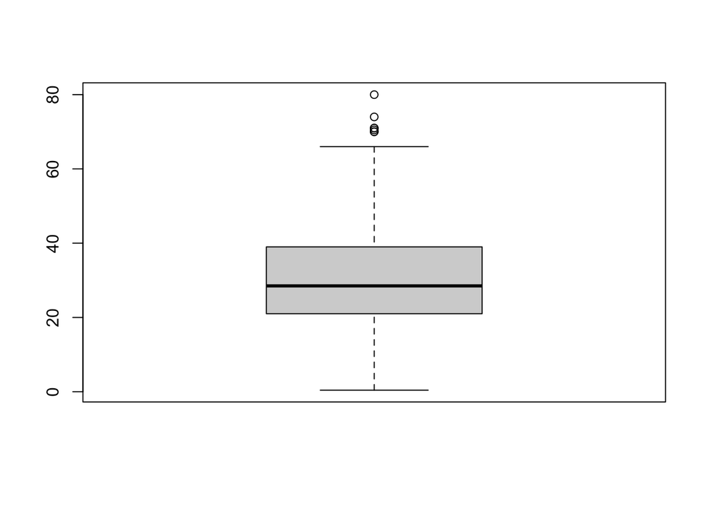

```r
boxplot(titanic_clean$Age)
```

```r
boxplot.stats(titanic_clean$Age)
```

```
## $stats
## [1]  0.42 21.00 28.50 39.00 66.00
##
## $n
## [1] 891
##
## $conf
## [1] 27.54722 29.45278
##
## $out
## [1] 71.0 70.5 71.0 80.0 70.0 70.0 74.0
```

### 3.2.5 Análisis de la variable SibSp

```r
table(titanic_clean$SibSp)
```

| 0 | 1 | 2 | 3 | 4 | 5 | 8 |
| --- | --- | --- | --- | --- | --- | --- |
| 608 | 209 | 28 | 16 | 18 | 5 | 7 |

Como vemos, la mayor parte de los pasajeros viajaban solos sin hermanos/as esposos/as

### 3.2.6 Análisis de la variable Parch

```r
table(titanic_clean$Parch)
```

| 0 | 1 | 2 | 3 | 4 | 5 | 6 |
| --- | --- | --- | --- | --- | --- | --- |
| 678 | 118 | 80 | 5 | 4 | 5 | 1 |

como vemos, la mayor parte de los pasajeros viajaban solos sin padres o hijos

### 3.2.7 Análisis de la variable Fare

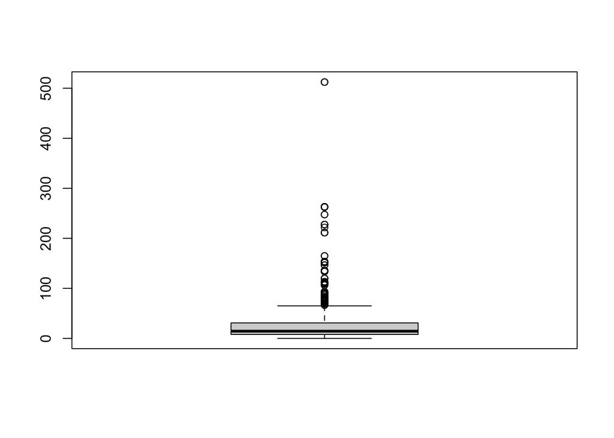

```r
boxplot(titanic_clean$Fare)
```

```r
boxplot.stats(titanic_clean$Fare)
```

```
## $stats
## [1]  0.0000  7.9104 14.4542 31.0000 65.0000
##
## $n
## [1] 891
##
## $conf
## [1] 13.23202 15.67638
##
## $out
##   [1]  71.2833 263.0000 146.5208  82.1708  76.7292  80.0000  83.4750  73.5000
##   [9] 263.0000  77.2875 247.5208  73.5000  77.2875  79.2000  66.6000  69.5500
##  [17]  69.5500 146.5208  69.5500 113.2750  76.2917  90.0000  83.4750  90.0000
##  [25]  79.2000  86.5000 512.3292  79.6500 153.4625 135.6333  77.9583  78.8500
##  [33]  91.0792 151.5500 247.5208 151.5500 110.8833 108.9000  83.1583 262.3750
##  [41] 164.8667 134.5000  69.5500 135.6333 153.4625 133.6500  66.6000 134.5000
##  [49] 263.0000  75.2500  69.3000 135.6333  82.1708 211.5000 227.5250  73.5000
##  [57] 120.0000 113.2750  90.0000 120.0000 263.0000  81.8583  89.1042  91.0792
##  [65]  90.0000  78.2667 151.5500  86.5000 108.9000  93.5000 221.7792 106.4250
##  [73]  71.0000 106.4250 110.8833 227.5250  79.6500 110.8833  79.6500  79.2000
##  [81]  78.2667 153.4625  77.9583  69.3000  76.7292  73.5000 113.2750 133.6500
##  [89]  73.5000 512.3292  76.7292 211.3375 110.8833 227.5250 151.5500 227.5250
##  [97] 211.3375 512.3292  78.8500 262.3750  71.0000  86.5000 120.0000  77.9583
## [105] 211.3375  79.2000  69.5500 120.0000  93.5000  80.0000  83.1583  69.5500
## [113]  89.1042 164.8667  69.5500  83.1583
```

Como vemos, la mayor parte del pasaje tenia tickets con un precio bajo. Los outliers que encontramos con precios muy por encima de la media podrían pertenecer a pasajeros que viajaban en los mejores camarotes y con una serie de servicios extras que podrían ser de lujo. Después de este razonamiento decidimos no eliminar los outliers de esta columna.

### 3.2.8 Análisis de la variable Embarked

```r
table(titanic_clean$Embarked)
```

| C | Q | S | unknown |
| --- | --- | --- | --- |
| 168 | 77 | 644 | 2 |

Vemos como estos datos pertenecen a los distintos puertos en los que se embarcó, a excepción de los catalogados como unknown que no se sabe donde lo hicieron

### 3.2.9 Análisis de la variable Ticket

```r
#para el análisis de esta variable vamos a eliminar del valor, la parte que contiene letras y quedarnos únicamente con la parte numérica
funcion_ticket <- function(x){
      if(!is.na(x)){
        sp_char <- strsplit(x, " ")[[1]]
        #print(sp_char)
        ticket_no1 <- sp_char[1]
        ticket_no2 <- sp_char[2]
        ticket_no3 <- sp_char[-1]
        #print(ticket_no3)
        #print(ticket_no1)
        #print(ticket_no2)
        if(is.na(ticket_no2)){
          ticket_no <- ticket_no1
        }else{
          ticket_no <- ticket_no2
        }
        x <- as.numeric(ticket_no)
      }
      return(x)
}
```

```r
# Aplico transformación y creo una nueva columna ticket2 con el valor corregido
titanic_clean$Ticket2 <- titanic_clean$Ticket %>% sapply(function(x) suppressWarnings(as.numeric(funcion_ticket(x))))
head(titanic_clean)
```

| Survived | Pclass | Name | Sex | Age | SibSp | Parch | Ticket | Fare | Embarked | Ticket2 |
| --- | --- | --- | --- | --- | --- | --- | --- | --- | --- | --- |
| 0 | 3 | Braund, Mr. Owen Harris | male | 22 | 1 | 0 | A/5 21171 | 7.2500 | S | 21171 |
| 1 | 1 | Cumings, Mrs. John Bradley (Florence Briggs Thayer) | female | 38 | 1 | 0 | PC 17599 | 71.2833 | C | 17599 |
| 1 | 3 | Heikkinen, Miss. Laina | female | 26 | 0 | 0 | STON/O2. 3101282 | 7.9250 | S | 3101282 |
| 1 | 1 | Futrelle, Mrs. Jacques Heath (Lily May Peel) | female | 35 | 1 | 0 | 113803 | 53.1000 | S | 113803 |
| 0 | 3 | Allen, Mr. William Henry | male | 35 | 0 | 0 | 373450 | 8.0500 | S | 373450 |
| 0 | 3 | Moran, Mr. James | male | 33 | 0 | 0 | 330877 | 8.4583 | Q | 330877 |

Al hacer esta modificación todos pasajeros que tienen LINE en ticket se me genera una NA, Como no tengo claro que Ticket pueda ser una variable útil para realizar el análisis posterior, decido mantener estos pasajeros. De otro modo, podríamos hacer un drop NAs y eliminar estas 5 filas.

```r
# vemos como ya no tenemos valores cero en el atributo age
# Estadísticas de valores vacíos
colSums(is.na(titanic_clean))
```

```
## Survived   Pclass     Name      Sex      Age    SibSp    Parch   Ticket
##        0        0        0        0        0        0        0        0
##     Fare Embarked  Ticket2
##        0        0        5
```

# 4 Análisis de los datos.

## 4.1 Selección de los grupos de datos que se quieren analizar/comparar (planificación de los análisis a aplicar).

Del conjunto de datos “test.csv” queremos verificar que pasajeros sobrevivieron, por tanto, realizaremos un modelo usando como variable dependiente “Survived” y verificaremos que variables independientes maximizan la bondad del modelo. Para el desarrollo del modelo haremos uso del dataset de entrenamiento “train.csv”

## 4.2 Comprobación de la normalidad y homogeneidad de la varianza.

Asumiendo como hipótesis nula que la población está distribuida normalmente, si el p-valor es menor al nivel de significancia, generalmente, entonces la hipótesis nula es rechazada y se concluye que los datos no cuentan con una distribución normal. Si, por el contrario, el p-valor es mayor, se concluye que no se puede rechazar dicha hipótesis y se asume que los datos siguen una distribución normal.

Realizo un análisis de normalidad de las variables cuantitativas de forma grafica y aplicando los métodos para verificar la normalidad

#### 4.2.0.1 Age

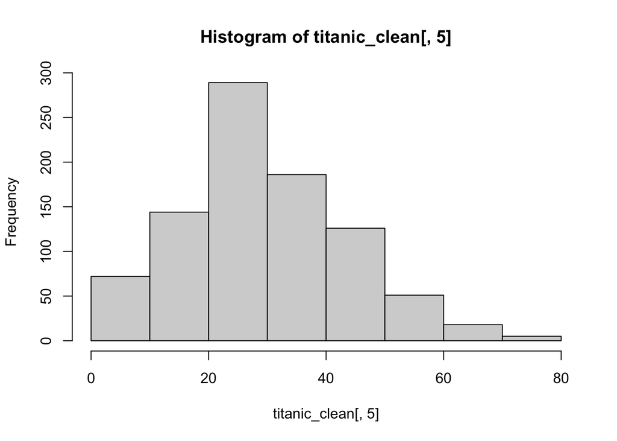

```r
#Age
###Histograma###
hist(titanic_clean[,5])
```

```r
library(normtest)
library(nortest)
library(moments)
```

```r
###Prueba de Anderson-Darling###
ad.test(titanic_clean[,5])
```

```
##
##  Anderson-Darling normality test
##
## data:  titanic_clean[, 5]
## A = 3.3796, p-value = 1.853e-08
```

```r
###Prueba de Lilliefors
lillie.test(titanic_clean[,5])
```

```
##
##  Lilliefors (Kolmogorov-Smirnov) normality test
##
## data:  titanic_clean[, 5]
## D = 0.061499, p-value = 1.856e-08
```

```r
###Prueba de Jarque Bera###
jb.norm.test(titanic_clean[,5])
```

```
##
##  Jarque-Bera test for normality
##
## data:  titanic_clean[, 5]
## JB = 20.12, p-value < 2.2e-16
```

```r
###Prueba de Frosini###
frosini.norm.test(titanic_clean[,5])
```

```
##
##  Frosini test for normality
##
## data:  titanic_clean[, 5]
## B = 0.60557, p-value < 2.2e-16
```

#### 4.2.0.2 Fare

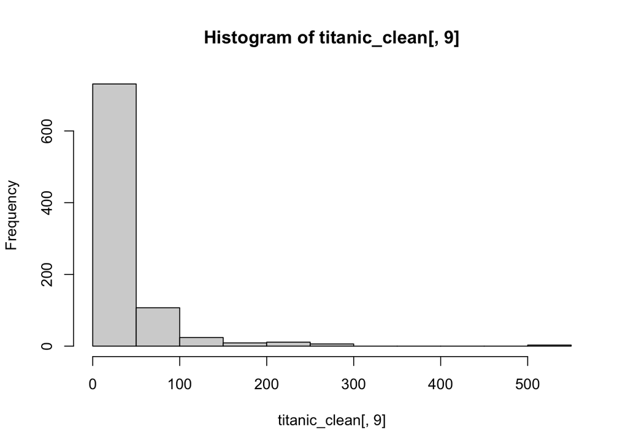

```r
#Fare
###Histograma###
hist(titanic_clean[,9])
```

```r
###Prueba de Frosini###
frosini.norm.test(titanic_clean[,9])
```

```
##
##  Frosini test for normality
##
## data:  titanic_clean[, 9]
## B = 4.2277, p-value < 2.2e-16
```

#### 4.2.0.3 Ticket2

```r
###Prueba de Frosini###
frosini.norm.test(titanic_clean[,11])
```

```
##
##  Frosini test for normality
##
## data:  titanic_clean[, 11]
## B = 4.882, p-value < 2.2e-16
```

Hipótesis

H0: La muestra proviene de una distribución normal.

H1: La muestra no proviene de una distribución normal.

El nivel de significancia que se trabajará es de 0.05. Alfa=0.05

Criterio de Decisión

Si P < Alfa Se rechaza Ho

Si p >= Alfa No se rechaza Ho

Como vemos en todos los análisis realizados para comprobar la normalidad nuestros p valores son mucho más pequeños que nuestro alfa 0.05, por tanto, rechazaríamos la hipótesis nula y diríamos que nuestra muestra no proviene de una distribución normal.

### 4.2.1 Homogeneidad

Comprobación de la homocedasticidad. Algunas pruebas estadísticas requieren la comprobación previa de la homocedasticidad en los datos, es decir, de la igualdad de varianzas entre los grupos que se van a comparar. Entre las pruebas más habituales se encuentra el test de Levene, que se aplica cuando los datos siguen una distribución normal, así́ como el test de Fligner-Killeen, que se trata de la alternativa no paramétrica, utilizada cuando los datos no cumplen con la condición de normalidad. En ambas pruebas, la hipótesis nula asume igualdad de varianzas en los diferentes grupos de datos, por lo que p-valores inferiores al nivel de significancia indicaran heterocedasticidad.

Aplico el test para verificar la homogeneidad entre Survived y Age

```r
fligner.test(Survived ~ Age, data = titanic_clean)
```

```
##
##  Fligner-Killeen test of homogeneity of variances
##
## data:  Survived by Age
## Fligner-Killeen:med chi-squared = 111.1, df = 87, p-value = 0.04177
```

## 4.3 Aplicación de pruebas estadísticas para comparar los grupos de datos. En función de los datos y el objetivo del estudio, aplicar pruebas de contraste de hipótesis, correlaciones, regresiones, etc. Aplicar al menos tres métodos de análisis diferentes.

### 4.3.1 Correlacion

Ya que nos gustaría conocer si un pasajero del Titanic puede sobrevivir o no, vamos a comprobar cual es la correlación de la variable dependiente *Survived* con las variables independientes del dataset.

```r
library(ggcorrplot)
# para poder analizar la correlacion de las variables cualitativas, genero columnas dummy para estos valores
titanic_corr <- fastDummies::dummy_cols(titanic_clean, select_columns = c('Sex','Embarked'))
#corr <- cor(titanic_clean[, c('Survived', 'Pclass', 'Sex', 'Age', 'SibSp', 'Parch', 'Fare')])
```

```r
# calculo la correlacion
#corr <- cor(titanic_corr[, c('Age','Survived','Sex_male','Sex_female','Pclass','SibSp','Parch','Fare','Embarked_C','Embarked_Q','Embarked_S')])
```

```r
# calculo la correlacion
corr <- cor(titanic_corr[, c('Age','SibSp','Parch','Fare')])
```

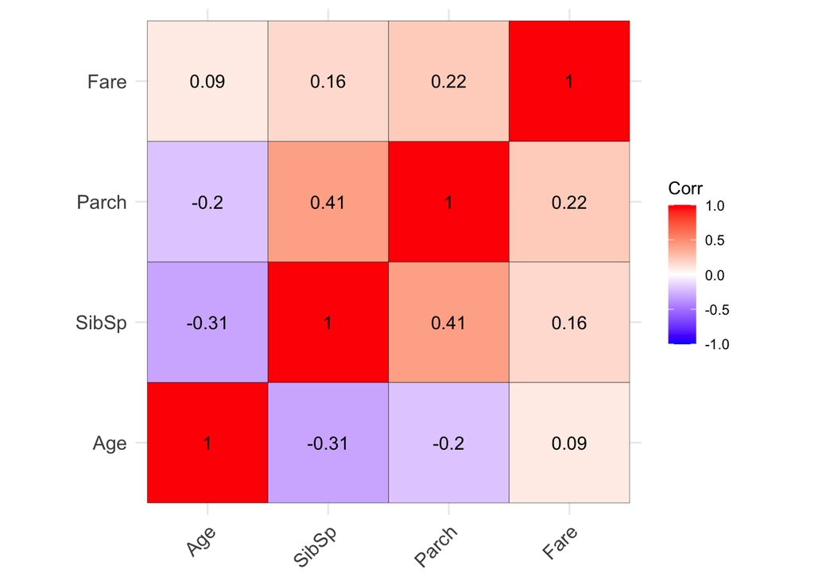

```r
ggcorrplot(corr, outline.col = "black", lab=TRUE)
```

Se observa una minima correlacion (0.41) entre Parch y SibSp

### 4.3.2 Contraste de hipótesis

```r
tabla <- table(titanic_clean$Survived, titanic_clean$Sex)
tabla
```

| / | female | male |
| --- | --- | --- |
| 0 | 81 | 468 |
| 1 | 233 | 109 |

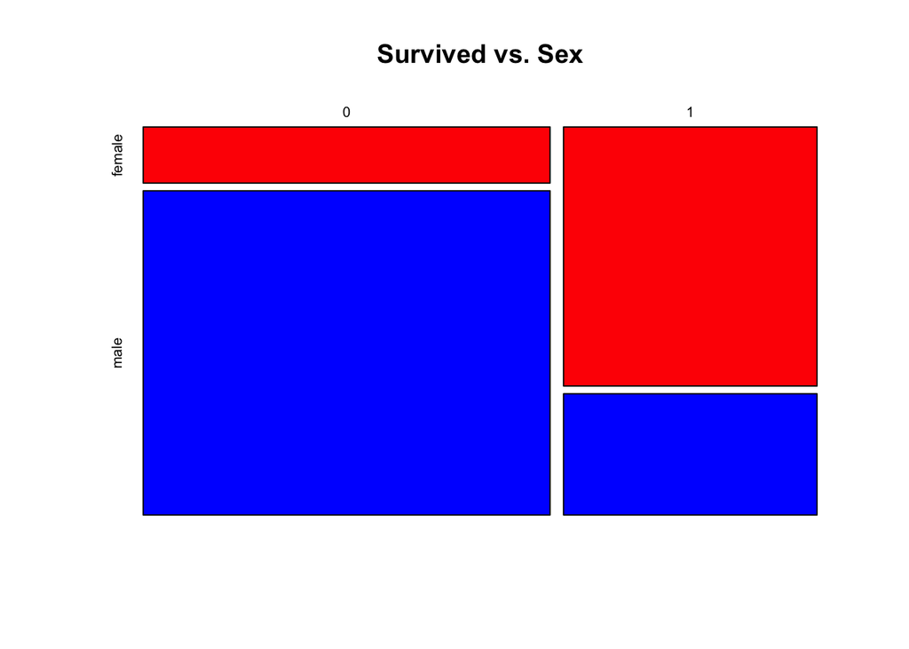

```r
plot(tabla, col = c("red", "blue"), main = "Survived vs. Sex")
```

```r
#verificamos la relacion entre Survived y Sex
chisq.test(tabla)
```

```
##
##  Pearson's Chi-squared test with Yates' continuity correction
##
## data:  tabla
## X-squared = 260.72, df = 1, p-value < 2.2e-16
```

Dado que el p valor es inferior al valor de alfa, con el nivel de significación de 0.05 podemos rechazar la hipótesis nula, por lo que podemos considerar que el sexo afecta a la supervivencia, ya que parece que el género es un buen indicador.

### 4.3.3 Aplicacion de la regresión logística

```r
## Convierto "Survived","Pclass","Sex","Embarked" a factor
for (i in c("Survived","Pclass","Sex","Embarked")){
  titanic_clean[,i]=as.factor(titanic_clean[,i])
}
```

```r
# genero un primer modelo con todas las variables dependientes del dataset
modelo <- glm(Survived ~ Pclass+Sex+Age+SibSp+Parch+Fare+Embarked,family=binomial(link='logit'),data=titanic_clean)
summary(modelo)
```

```
##
## Call:
## glm(formula = Survived ~ Pclass + Sex + Age + SibSp + Parch +
##     Fare + Embarked, family = binomial(link = "logit"), data = titanic_clean)
##
## Deviance Residuals:
##     Min       1Q   Median       3Q      Max
## -2.8173  -0.5998  -0.3579   0.6099   2.5406
##
## Coefficients:
##                   Estimate Std. Error z value Pr(>|z|)
## (Intercept)       4.810426   0.503948   9.545  < 2e-16 ***
## Pclass2          -1.256082   0.311019  -4.039 5.38e-05 ***
## Pclass3          -2.536637   0.316376  -8.018 1.08e-15 ***
## Sexmale          -2.656585   0.204310 -13.003  < 2e-16 ***
## Age              -0.053879   0.008065  -6.681 2.38e-11 ***
## SibSp            -0.390025   0.112600  -3.464 0.000533 ***
## Parch            -0.089563   0.122975  -0.728 0.466428
## Fare              0.001362   0.002429   0.561 0.574943
## EmbarkedQ        -0.315693   0.402015  -0.785 0.432291
## EmbarkedS        -0.390423   0.243901  -1.601 0.109434
## Embarkedunknown  12.458814 600.408278   0.021 0.983445
## ---
## Signif. codes:  0 '***' 0.001 '**' 0.01 '*' 0.05 '.' 0.1 ' ' 1
##
## (Dispersion parameter for binomial family taken to be 1)
##
##     Null deviance: 1186.66  on 890  degrees of freedom
## Residual deviance:  760.32  on 880  degrees of freedom
## AIC: 782.32
##
## Number of Fisher Scoring iterations: 13
```

Del summary del modelo anterior vemos como las variables Parch, Fare y Embarked tienen una significancia baja por lo que podrían eliminarse del modelo.

Si aplicamos de nuevo la regresión logística, pero sin las variables mencionadas anteriormente, vemos como baja el AIC y por tanto como se ha mejorado el modelo.

```r
modelo <- glm(Survived ~ Pclass+Sex+Age+SibSp,family=binomial(link='logit'),data=titanic_clean)
summary(modelo)
```

```
##
## Call:
## glm(formula = Survived ~ Pclass + Sex + Age + SibSp, family = binomial(link = "logit"),
##     data = titanic_clean)
##
## Deviance Residuals:
##     Min       1Q   Median       3Q      Max
## -2.8962  -0.6019  -0.3511   0.6310   2.5306
##
## Coefficients:
##              Estimate Std. Error z value Pr(>|z|)
## (Intercept)  4.711146   0.422539  11.150  < 2e-16 ***
## Pclass2     -1.468944   0.272657  -5.388 7.14e-08 ***
## Pclass3     -2.733519   0.265533 -10.294  < 2e-16 ***
## Sexmale     -2.656797   0.196497 -13.521  < 2e-16 ***
## Age         -0.055142   0.007938  -6.946 3.75e-12 ***
## SibSp       -0.422058   0.106104  -3.978 6.96e-05 ***
## ---
## Signif. codes:  0 '***' 0.001 '**' 0.01 '*' 0.05 '.' 0.1 ' ' 1
##
## (Dispersion parameter for binomial family taken to be 1)
##
##     Null deviance: 1186.66  on 890  degrees of freedom
## Residual deviance:  764.55  on 885  degrees of freedom
## AIC: 776.55
##
## Number of Fisher Scoring iterations: 5
```

# 5 Representación de los resultados a partir de tablas y gráficas.

## 5.1 Representacion de los supervivientes por sexo

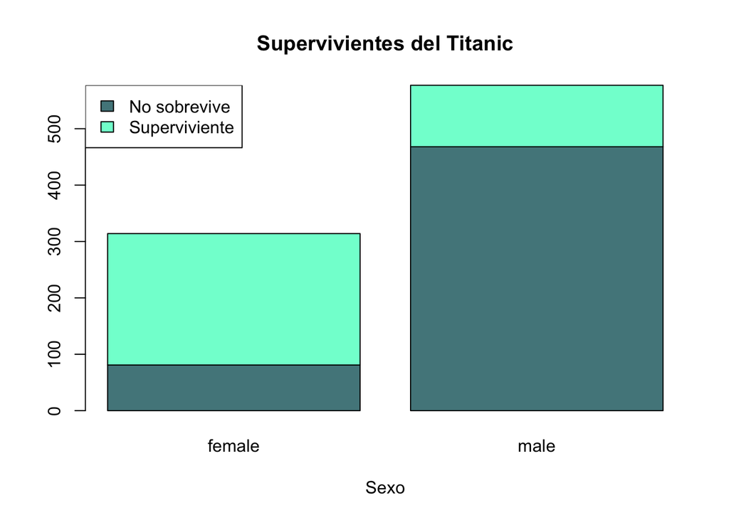

```r
titanic.data<-table(titanic_clean[,c(1,4)])
barplot(titanic.data, main = "Supervivientes del Titanic", xlab = "Sexo",col= c("cadetblue4","aquamarine"))
legend("topleft", c("No sobrevive","Superviviente"), fill = c("cadetblue4","aquamarine"))
```

Vamos a calcular el odds-ratio de cada una de las variables que hemos utilizado en nuestro modelo de regresión logística para evaluar si un pasajero del titanic sobreviviría o no.

```r
exp(coefficients(modelo))
```

```
##  (Intercept)      Pclass2      Pclass3      Sexmale          Age        SibSp
## 111.17955205   0.23016844   0.06499016   0.07017261   0.94635106   0.65569593
```

## 5.2 ROC

```r
library(pROC)
p <- predict(modelo, titanic_clean[, c("Pclass","Sex","Age","SibSp")], type="response")
r <- roc(titanic_clean$Survived, p, data=titanic_clean)
```

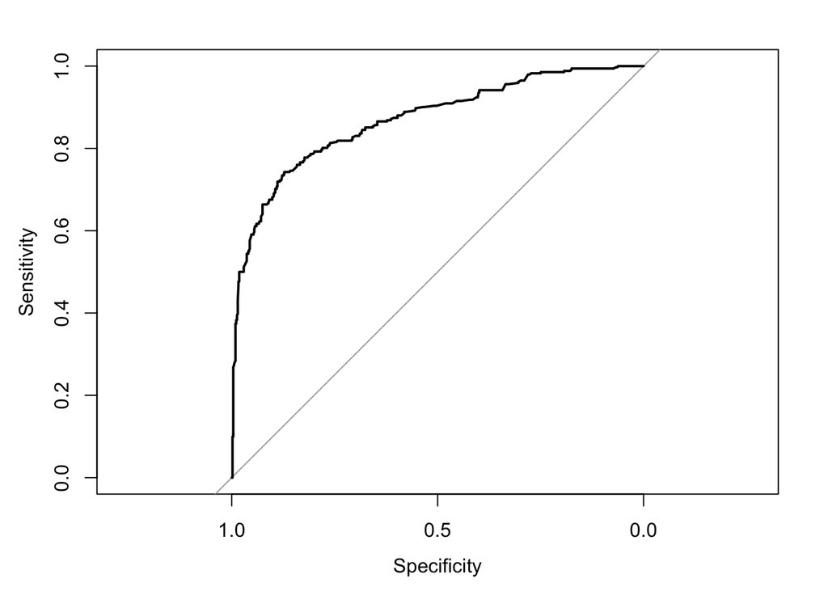

```r
plot(r)
```

```r
auc(r)
```

```
## Area under the curve: 0.8689
```

# 6 Resolución del problema. A partir de los resultados obtenidos, ¿cuáles son las conclusiones? ¿Los resultados permiten responder al problema?

Para evaluar el modelo, decidimos ponerlo en practica con el dataset de prueba.

```r
train <- read.csv('test.csv', stringsAsFactors = FALSE)
my_newdata <- train
```

Cargo el datset de los pasajeros del conjunto de test para evaluar si sobreviven al naufragio o no

```r
#Eliminamos la columna 4 que contiene los nombres de los pasajeros
#Creamos un nuevo dataset con los datos limpios "titanic_clean"
my_newdata <- my_newdata[, -(3:3)]
```

```r
#Eliminamos la columna 1 PassengerID
my_newdata <- my_newdata[, -(1:1)]
```

```r
#Eliminamos la columna Ticket
my_newdata <- my_newdata[, -(6:6)]
```

```r
#Eliminamos la columna Fare
my_newdata <- my_newdata[, -(7:7)]
```

```r
#Eliminamos la columna Parch
my_newdata <- my_newdata[, -(5:5)]
```

```r
#Eliminamos la columna Fare
my_newdata <- my_newdata[, -(5:5)]
```

```r
#Eliminamos la columna Embarked
my_newdata <- my_newdata[, -(5:5)]
```

```r
#convierto Pclass a numerico
my_newdata$Pclass <- as.factor(my_newdata$Pclass)
```

```r
# Este dataframe tiene Edades sin registrar. Tomamos la media para valores vacíos de la variable "Age"
my_newdata$Age[is.na(my_newdata$Age)] <- mean(my_newdata$Age,na.rm=T)
```

```r
#Aplicamos la prediccion a los datos aplicando el modelo
predict_value <- predict(modelo, my_newdata, type = "response")
# Como Survived solo puede ser 1 o 0, escribimos una instruccion para realizar el redondeo
# Since Survived can only be either 1 or 0, write if statement to round up of down the response
predict_value <- ifelse(predict_value>0.5,1,0)
predict_value
```

```
##   1   2   3   4   5   6   7   8   9  10  11  12  13  14  15  16  17  18  19  20
##   0   0   0   0   1   0   1   0   1   0   0   0   1   0   1   1   0   0   1   0
##  21  22  23  24  25  26  27  28  29  30  31  32  33  34  35  36  37  38  39  40
##   0   0   1   1   1   0   1   0   0   0   0   0   0   0   0   0   1   1   0   0
##  41  42  43  44  45  46  47  48  49  50  51  52  53  54  55  56  57  58  59  60
##   0   1   0   1   1   0   0   0   1   0   1   0   1   1   0   0   0   0   0   1
##  61  62  63  64  65  66  67  68  69  70  71  72  73  74  75  76  77  78  79  80
##   0   0   0   1   1   1   1   0   1   1   1   0   1   1   1   1   0   1   0   1
##  81  82  83  84  85  86  87  88  89  90  91  92  93  94  95  96  97  98  99 100
##   0   0   0   0   0   0   1   1   1   1   1   0   1   0   1   0   1   0   1   0
## 101 102 103 104 105 106 107 108 109 110 111 112 113 114 115 116 117 118 119 120
##   1   0   0   0   1   0   0   0   0   0   0   1   1   1   1   0   0   1   1   1
## 121 122 123 124 125 126 127 128 129 130 131 132 133 134 135 136 137 138 139 140
##   1   0   1   0   0   1   0   0   0   0   0   0   1   0   0   0   0   0   1   0
## 141 142 143 144 145 146 147 148 149 150 151 152 153 154 155 156 157 158 159 160
```

[output cut: 27 more lines]

```r
pronostico <- data.frame('PassengerId' = train$Name,'Survived' = as.factor(predict_value))
head(pronostico)
```

| PassengerId | Survived |
| --- | --- |
| Kelly, Mr. James | 0 |
| Wilkes, Mrs. James (Ellen Needs) | 0 |
| Myles, Mr. Thomas Francis | 0 |
| Wirz, Mr. Albert | 0 |
| Hirvonen, Mrs. Alexander (Helga E Lindqvist) | 1 |
| Svensson, Mr. Johan Cervin | 0 |

```r
#escribimos en un archivo csv nuestra prediccion sobre los pasajeros del conjunto de entrenamiento
write.csv(pronostico,"output.csv",sep=",")
```

Sería interesante calcular la ROC del conjunto de test, lamentablemente del lugar donde he descargado los datos https://www.kaggle.com/c/titanic, no disponemos de la columna Survived del dataset para realizar este cálculo.

# 7 Código: Hay que adjuntar el código, preferiblemente en R, con el que se ha realizado la limpieza, análisis y representación de los datos. Si lo preferís, también podéis trabajar en Python.s.

# 8 Contribución

| Contribuciones | Firma |
| --- | --- |
| Investigación previa | DLU |
| Redacción de respuestas | DLU |
| Desarrollo de código | DLU |